# Unsupervised Learning Project

#### Part 1.3 c - On the above visual, highlight which are the possible Elbow points.

##### Below are the highligfhted elbow points

[figure not shown]

```python
#Part 1.3 d - Train a K-means clustering model once again on the optimal number of clusters.

# Optimal number of clusters
optimal_clusters = 3

# Train K-Means clustering model
kmeans = KMeans(n_clusters=optimal_clusters, random_state=0)
kmeans.fit(X)

# Add cluster labels to the dataframe
car_data['cluster'] = kmeans.labels_

# Print the cluster assignments
print("Cluster assignments:")
print(car_data[['mpg', 'cyl', 'disp', 'wt', 'acc', 'yr', 'origin', 'cluster']])
```

```
Cluster assignments:
      mpg  cyl   disp    wt   acc  yr  origin  cluster
0    18.0    8  307.0  3504  12.0  70       1        2
1    15.0    8  350.0  3693  11.5  70       1        0
2    18.0    8  318.0  3436  11.0  70       1        2
3    16.0    8  304.0  3433  12.0  70       1        2
4    17.0    8  302.0  3449  10.5  70       1        2
..    ...  ...    ...   ...   ...  ..     ...      ...
393  27.0    4  140.0  2790  15.6  82       1        2
394  44.0    4   97.0  2130  24.6  82       2        1
395  32.0    4  135.0  2295  11.6  82       1        1
396  28.0    4  120.0  2625  18.6  82       1        1
397  31.0    4  119.0  2720  19.4  82       1        2

[398 rows x 8 columns]
```

```python
#Part 1.3 e - Add a new feature in the DataFrame which will have labels based upon cluster value


# Map cluster values to labels
cluster_labels = {0: 'Cluster 0', 1: 'Cluster 1', 2: 'Cluster 2'}
car_data['cluster_label'] = car_data['cluster'].map(cluster_labels)

# Print the dataframe with cluster labels
print("DataFrame with Cluster Labels:")
print(car_data)
```

```
DataFrame with Cluster Labels:
      mpg  cyl   disp     hp    wt   acc  yr  origin  \
0    18.0    8  307.0  130.0  3504  12.0  70       1
1    15.0    8  350.0  165.0  3693  11.5  70       1
2    18.0    8  318.0  150.0  3436  11.0  70       1
3    16.0    8  304.0  150.0  3433  12.0  70       1
4    17.0    8  302.0  140.0  3449  10.5  70       1
..    ...  ...    ...    ...   ...   ...  ..     ...
393  27.0    4  140.0   86.0  2790  15.6  82       1
394  44.0    4   97.0   52.0  2130  24.6  82       2
395  32.0    4  135.0   84.0  2295  11.6  82       1
396  28.0    4  120.0   79.0  2625  18.6  82       1
397  31.0    4  119.0   82.0  2720  19.4  82       1

                      car_name  cluster cluster_label
0    chevrolet chevelle malibu        2     Cluster 2
1            buick skylark 320        0     Cluster 0
2           plymouth satellite        2     Cluster 2
3                amc rebel sst        2     Cluster 2
4                  ford torino        2     Cluster 2
..                         ...      ...           ...
393            ford mustang gl        2     Cluster 2
394                  vw pickup        1     Cluster 1
395              dodge rampage        1     Cluster 1
396                ford ranger        1     Cluster 1
397                 chevy s-10        2     Cluster 2

[398 rows x 11 columns]
```

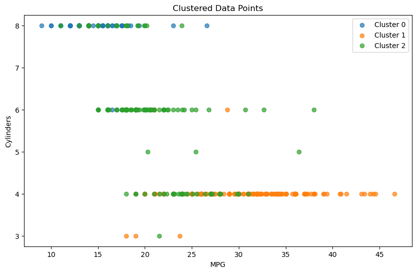

```python
#Part 1.3 f -Plot a visual and color the datapoints based upon clusters.

# Create a scatter plot with colored data points based on clusters
plt.figure(figsize=(10, 6))
for cluster_id, cluster_label in cluster_labels.items():
    cluster_data = car_data[car_data['cluster'] == cluster_id]
    plt.scatter(cluster_data['mpg'], cluster_data['cyl'], label=cluster_label, alpha=0.7)

plt.xlabel('MPG')
plt.ylabel('Cylinders')
plt.title('Clustered Data Points')
plt.legend()
plt.show()
```

```python
#Part 1.3 g - Pass a new DataPoint and predict which cluster it belongs to.

# New data point to predict (replace with actual values)
new_data_point = [[20, 4, 150, 2500, 15, 80, 1]]

# Predict which cluster the new data point belongs to
predicted_cluster = kmeans.predict(new_data_point)

print(f"The new data point belongs to Cluster {predicted_cluster[0]}")
```

```
The new data point belongs to Cluster 1
```

```python
#Part 2. 1 a - Read ‘vehicle.csv’ and save as DataFrame.

vehicle_data = pd.read_csv("vehicle.csv")
vehicle_data.head(5)
```

|  | compactness | circularity | distance_circularity | radius_ratio | pr.axis_aspect_ratio | max.length_aspect_ratio | scatter_ratio | elongatedness | pr.axis_rectangularity | max.length_rectangularity | scaled_variance | scaled_variance.1 | scaled_radius_of_gyration | scaled_radius_of_gyration.1 | skewness_about | skewness_about.1 | skewness_about.2 | hollows_ratio | class |
| --- | --- | --- | --- | --- | --- | --- | --- | --- | --- | --- | --- | --- | --- | --- | --- | --- | --- | --- | --- |
| 0 | 95 | 48.0 | 83.0 | 178.0 | 72.0 | 10 | 162.0 | 42.0 | 20.0 | 159 | 176.0 | 379.0 | 184.0 | 70.0 | 6.0 | 16.0 | 187.0 | 197 | van |
| 1 | 91 | 41.0 | 84.0 | 141.0 | 57.0 | 9 | 149.0 | 45.0 | 19.0 | 143 | 170.0 | 330.0 | 158.0 | 72.0 | 9.0 | 14.0 | 189.0 | 199 | van |
| 2 | 104 | 50.0 | 106.0 | 209.0 | 66.0 | 10 | 207.0 | 32.0 | 23.0 | 158 | 223.0 | 635.0 | 220.0 | 73.0 | 14.0 | 9.0 | 188.0 | 196 | car |
| 3 | 93 | 41.0 | 82.0 | 159.0 | 63.0 | 9 | 144.0 | 46.0 | 19.0 | 143 | 160.0 | 309.0 | 127.0 | 63.0 | 6.0 | 10.0 | 199.0 | 207 | van |
| 4 | 85 | 44.0 | 70.0 | 205.0 | 103.0 | 52 | 149.0 | 45.0 | 19.0 | 144 | 241.0 | 325.0 | 188.0 | 127.0 | 9.0 | 11.0 | 180.0 | 183 | bus |

```python
vehicle_data.info()
```

```
<class 'pandas.core.frame.DataFrame'>
RangeIndex: 846 entries, 0 to 845
Data columns (total 19 columns):
 #   Column                       Non-Null Count  Dtype
---  ------                       --------------  -----
 0   compactness                  846 non-null    int64
 1   circularity                  841 non-null    float64
 2   distance_circularity         842 non-null    float64
 3   radius_ratio                 840 non-null    float64
 4   pr.axis_aspect_ratio         844 non-null    float64
 5   max.length_aspect_ratio      846 non-null    int64
 6   scatter_ratio                845 non-null    float64
 7   elongatedness                845 non-null    float64
 8   pr.axis_rectangularity       843 non-null    float64
 9   max.length_rectangularity    846 non-null    int64
 10  scaled_variance              843 non-null    float64
 11  scaled_variance.1            844 non-null    float64
 12  scaled_radius_of_gyration    844 non-null    float64
 13  scaled_radius_of_gyration.1  842 non-null    float64
 14  skewness_about               840 non-null    float64
 15  skewness_about.1             845 non-null    float64
 16  skewness_about.2             845 non-null    float64
 17  hollows_ratio                846 non-null    int64
 18  class                        846 non-null    object
dtypes: float64(14), int64(4), object(1)
memory usage: 125.7+ KB
```

```python
vehicle_data.describe()
```

|  | compactness | circularity | distance_circularity | radius_ratio | pr.axis_aspect_ratio | max.length_aspect_ratio | scatter_ratio | elongatedness | pr.axis_rectangularity | max.length_rectangularity | scaled_variance | scaled_variance.1 | scaled_radius_of_gyration | scaled_radius_of_gyration.1 | skewness_about | skewness_about.1 | skewness_about.2 | hollows_ratio |
| --- | --- | --- | --- | --- | --- | --- | --- | --- | --- | --- | --- | --- | --- | --- | --- | --- | --- | --- |
| count | 846.000000 | 841.000000 | 842.000000 | 840.000000 | 844.000000 | 846.000000 | 845.000000 | 845.000000 | 843.000000 | 846.000000 | 843.000000 | 844.000000 | 844.000000 | 842.000000 | 840.000000 | 845.000000 | 845.000000 | 846.000000 |
| mean | 93.678487 | 44.828775 | 82.110451 | 168.888095 | 61.678910 | 8.567376 | 168.901775 | 40.933728 | 20.582444 | 147.998818 | 188.631079 | 439.494076 | 174.709716 | 72.447743 | 6.364286 | 12.602367 | 188.919527 | 195.632388 |
| std | 8.234474 | 6.152172 | 15.778292 | 33.520198 | 7.891463 | 4.601217 | 33.214848 | 7.816186 | 2.592933 | 14.515652 | 31.411004 | 176.666903 | 32.584808 | 7.486190 | 4.920649 | 8.936081 | 6.155809 | 7.438797 |
| min | 73.000000 | 33.000000 | 40.000000 | 104.000000 | 47.000000 | 2.000000 | 112.000000 | 26.000000 | 17.000000 | 118.000000 | 130.000000 | 184.000000 | 109.000000 | 59.000000 | 0.000000 | 0.000000 | 176.000000 | 181.000000 |
| 25% | 87.000000 | 40.000000 | 70.000000 | 141.000000 | 57.000000 | 7.000000 | 147.000000 | 33.000000 | 19.000000 | 137.000000 | 167.000000 | 318.000000 | 149.000000 | 67.000000 | 2.000000 | 5.000000 | 184.000000 | 190.250000 |
| 50% | 93.000000 | 44.000000 | 80.000000 | 167.000000 | 61.000000 | 8.000000 | 157.000000 | 43.000000 | 20.000000 | 146.000000 | 179.000000 | 363.500000 | 173.500000 | 71.500000 | 6.000000 | 11.000000 | 188.000000 | 197.000000 |
| 75% | 100.000000 | 49.000000 | 98.000000 | 195.000000 | 65.000000 | 10.000000 | 198.000000 | 46.000000 | 23.000000 | 159.000000 | 217.000000 | 587.000000 | 198.000000 | 75.000000 | 9.000000 | 19.000000 | 193.000000 | 201.000000 |
| max | 119.000000 | 59.000000 | 112.000000 | 333.000000 | 138.000000 | 55.000000 | 265.000000 | 61.000000 | 29.000000 | 188.000000 | 320.000000 | 1018.000000 | 268.000000 | 135.000000 | 22.000000 | 41.000000 | 206.000000 | 211.000000 |

```python
#Part 2.1 b- Check percentage of missing values and impute with correct approach.


# Calculate missing value percentage
missing_percentage = (vehicle_data.isnull().sum() / len(vehicle_data)) * 100

print("Missing Value Percentage:")
print(missing_percentage)
```

```
Missing Value Percentage:
compactness                    0.000000
circularity                    0.591017
distance_circularity           0.472813
radius_ratio                   0.709220
pr.axis_aspect_ratio           0.236407
max.length_aspect_ratio        0.000000
scatter_ratio                  0.118203
elongatedness                  0.118203
pr.axis_rectangularity         0.354610
max.length_rectangularity      0.000000
scaled_variance                0.354610
scaled_variance.1              0.236407
scaled_radius_of_gyration      0.236407
scaled_radius_of_gyration.1    0.472813
skewness_about                 0.709220
skewness_about.1               0.118203
skewness_about.2               0.118203
hollows_ratio                  0.000000
class                          0.000000
dtype: float64
```

```python
# Impute missing values based on appropriate approach
# You can replace these with your actual imputation methods
vehicle_data['circularity'].fillna(vehicle_data['circularity'].mean(), inplace=True)
vehicle_data['distance_circularity'].fillna(vehicle_data['distance_circularity'].mean(), inplace=True)
vehicle_data['radius_ratio'].fillna(vehicle_data['radius_ratio'].mean(), inplace=True)
vehicle_data['pr.axis_aspect_ratio'].fillna(vehicle_data['pr.axis_aspect_ratio'].mean(), inplace=True)
vehicle_data['scatter_ratio'].fillna(vehicle_data['scatter_ratio'].mean(), inplace=True)
vehicle_data['elongatedness'].fillna(vehicle_data['elongatedness'].mean(), inplace=True)
vehicle_data['pr.axis_rectangularity'].fillna(vehicle_data['pr.axis_rectangularity'].mean(), inplace=True)
vehicle_data['scaled_variance'].fillna(vehicle_data['scaled_variance'].mean(), inplace=True)
vehicle_data['scaled_variance.1'].fillna(vehicle_data['scaled_variance.1'].mean(), inplace=True)
vehicle_data['scaled_radius_of_gyration'].fillna(vehicle_data['scaled_radius_of_gyration'].mean(), inplace=True)
vehicle_data['scaled_radius_of_gyration.1'].fillna(vehicle_data['scaled_radius_of_gyration.1'].mean(), inplace=True)
vehicle_data['skewness_about'].fillna(vehicle_data['skewness_about'].mean(), inplace=True)
vehicle_data['skewness_about.1'].fillna(vehicle_data['skewness_about.1'].mean(), inplace=True)
vehicle_data['skewness_about.2'].fillna(vehicle_data['skewness_about.2'].mean(), inplace=True)

print("\nDataFrame after Imputation:")
print(vehicle_data)
```

```
DataFrame after Imputation:
     compactness  circularity  distance_circularity  radius_ratio  \
0             95         48.0                  83.0         178.0
1             91         41.0                  84.0         141.0
2            104         50.0                 106.0         209.0
3             93         41.0                  82.0         159.0
4             85         44.0                  70.0         205.0
..           ...          ...                   ...           ...
841           93         39.0                  87.0         183.0
842           89         46.0                  84.0         163.0
843          106         54.0                 101.0         222.0
844           86         36.0                  78.0         146.0
845           85         36.0                  66.0         123.0

     pr.axis_aspect_ratio  max.length_aspect_ratio  scatter_ratio  \
```

[output cut: 65 more lines]

```python
# Calculate missing value percentage again
missing_percentage = (vehicle_data.isnull().sum() / len(vehicle_data)) * 100

print("Missing Value Percentage after imputation:")
print(missing_percentage)
```

```
Missing Value Percentage after imputation:
compactness                    0.0
circularity                    0.0
distance_circularity           0.0
radius_ratio                   0.0
pr.axis_aspect_ratio           0.0
max.length_aspect_ratio        0.0
scatter_ratio                  0.0
elongatedness                  0.0
pr.axis_rectangularity         0.0
max.length_rectangularity      0.0
scaled_variance                0.0
scaled_variance.1              0.0
scaled_radius_of_gyration      0.0
scaled_radius_of_gyration.1    0.0
skewness_about                 0.0
skewness_about.1               0.0
skewness_about.2               0.0
hollows_ratio                  0.0
class                          0.0
dtype: float64
```

```
Percentage of Values for Variable 'class':
car    50.709220
bus    25.768322
van    23.522459
Name: class, dtype: float64
```

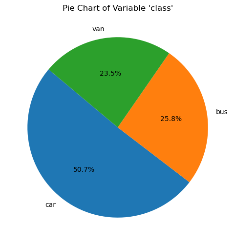

```python
#Part 2.1 c- Visualize a Pie-chart and print percentage of values for variable ‘class’.

# Calculate the value counts and percentages for the 'class' variable
class_counts = vehicle_data['class'].value_counts()
class_percentages = (class_counts / len(vehicle_data)) * 100

print("Percentage of Values for Variable 'class':")
print(class_percentages)

# Plot a pie chart
plt.figure(figsize=(6, 6))
plt.pie(class_counts, labels=class_counts.index, autopct='%1.1f%%', startangle=140)
plt.title("Pie Chart of Variable 'class'")
plt.show()
```

```python
#Part 2.1 d - Check for duplicate rows in the data and impute with correct approach.

# Identify duplicate rows
duplicate_rows = vehicle_data[vehicle_data.duplicated()]

print("Duplicate Rows:")
print(duplicate_rows)

# Impute duplicate rows based on appropriate approach
# You can drop duplicates, keep the first occurrence, or apply a specific imputation method
# For example, dropping duplicates:
df_no_duplicates = vehicle_data.drop_duplicates()

print("\nDataFrame without Duplicate Rows:")
print(df_no_duplicates)
```

```
Duplicate Rows:
Empty DataFrame
Columns: [compactness, circularity, distance_circularity, radius_ratio, pr.axis_aspect_ratio, max.length_aspect_ratio, scatter_ratio, elongatedness, pr.axis_rectangularity, max.length_rectangularity, scaled_variance, scaled_variance.1, scaled_radius_of_gyration, scaled_radius_of_gyration.1, skewness…
Index: []

DataFrame without Duplicate Rows:
     compactness  circularity  distance_circularity  radius_ratio  \
0             95         48.0                  83.0         178.0
1             91         41.0                  84.0         141.0
2            104         50.0                 106.0         209.0
3             93         41.0                  82.0         159.0
4             85         44.0                  70.0         205.0
..           ...          ...                   ...           ...
841           93         39.0                  87.0         183.0
842           89         46.0                  84.0         163.0
```

[output cut: 70 more lines]

```python
#Part 2.2 a - Split data into X and Y.

# Split data into X (features) and Y (target)
X = vehicle_data.drop('class', axis=1)  # Features
Y = vehicle_data['class']  # Target

print("X (Features):")
print(X)

print("\nY (Target):")
print(Y)
```

```
X (Features):
     compactness  circularity  distance_circularity  radius_ratio  \
0             95         48.0                  83.0         178.0
1             91         41.0                  84.0         141.0
2            104         50.0                 106.0         209.0
3             93         41.0                  82.0         159.0
4             85         44.0                  70.0         205.0
..           ...          ...                   ...           ...
841           93         39.0                  87.0         183.0
842           89         46.0                  84.0         163.0
843          106         54.0                 101.0         222.0
844           86         36.0                  78.0         146.0
845           85         36.0                  66.0         123.0

     pr.axis_aspect_ratio  max.length_aspect_ratio  scatter_ratio  \
```

[output cut: 79 more lines]

```python
#Part 2.2 b - Standardize the Data.

# Standardize the data
scaler = StandardScaler()
X_standardized = scaler.fit_transform(X)

print("Standardized Features (X_standardized):")
print(X_standardized)
```

```
Standardized Features (X_standardized):
[[ 0.16058035  0.51730193  0.05654535 ...  0.38066534 -0.31219283
   0.18395733]
 [-0.32546965 -0.62456401  0.12011169 ...  0.15658856  0.01308823
   0.45297703]
 [ 1.25419283  0.84354934  1.51857115 ... -0.40360337 -0.1495523
   0.04944748]
 ...
 [ 1.49721783  1.49604417  1.20073946 ... -0.96379531 -0.31219283
   0.72199673]
 [-0.93303214 -1.44018254 -0.26128634 ...  1.38901082  0.17572877
  -0.08506238]
 [-1.05454464 -1.44018254 -1.02408241 ...  0.60474211 -0.47483337
  -0.75761164]]
```

```python
#Part 2.3 a - Train a base Classification model using SVM.

# Split the data into train and test sets
X_train, X_test, Y_train, Y_test = train_test_split(X, Y, test_size=0.2, random_state=42)

# Train a base classification model using SVM
svm_model = SVC(kernel='linear')  # You can choose different kernels such as 'linear', 'poly', 'rbf', etc.
svm_model.fit(X_train, Y_train)

# Predict on the test set
Y_pred = svm_model.predict(X_test)

# Calculate accuracy
accuracy = accuracy_score(Y_test, Y_pred)
print("Accuracy:", accuracy)
```

```
Accuracy: 0.9352941176470588
```

```python
#Part 2.3 b - Print Classification metrics for train data.

# Predict on the training set
Y_train_pred = svm_model.predict(X_standardized)

# Print classification metrics
classification_metrics = classification_report(Y, Y_train_pred)
print("Classification Metrics for Train Data:")
print(classification_metrics)
```

```
Classification Metrics for Train Data:
              precision    recall  f1-score   support

         bus       0.00      0.00      0.00       218
         car       0.51      1.00      0.67       429
         van       0.00      0.00      0.00       199

    accuracy                           0.51       846
   macro avg       0.17      0.33      0.22       846
weighted avg       0.26      0.51      0.34       846
```

```python
#Part 2.3 c - Apply PCA on the data with 10 components.

# Apply PCA with 10 components
pca = PCA(n_components=10)
X_pca = pca.fit_transform(X_standardized)

print("PCA Transformed Features:")
print(X_pca)
```

```
PCA Transformed Features:
[[ 3.32393198e-01 -2.18638382e-01  1.00128619e+00 ... -3.83358279e-01
  -8.68964207e-01  8.85994765e-02]
 [-1.59374091e+00 -4.20549398e-01 -3.69264301e-01 ...  2.47624062e-01
   1.46541766e-01 -9.61040796e-02]
 [ 3.76753509e+00  1.95040767e-01  8.82372311e-02 ...  4.83438500e-01
  -3.08888459e-01 -4.69879602e-01]
 ...
 [ 4.80780979e+00 -1.82373823e-03  5.32772800e-01 ...  1.10917677e-01
  -6.52653571e-01  5.54811205e-01]
 [-3.29572788e+00 -1.00880341e+00 -3.57467658e-01 ...  3.19508398e-01
  -2.01552424e-01 -8.75978153e-01]
 [-4.76673461e+00  3.34686477e-01 -5.68739264e-01 ... -2.48355712e-01
  -4.31741589e-01 -3.02292784e-01]]
```

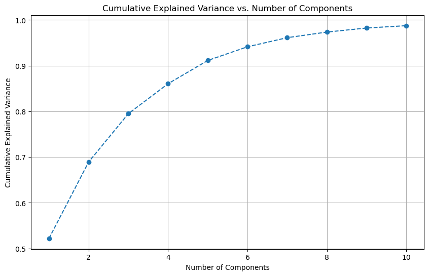

```python
#Part 2.3 d - Visualize Cumulative Variance Explained with Number of Components.

# Compute cumulative explained variance ratio
cumulative_variance = np.cumsum(pca.explained_variance_ratio_)

# Visualize cumulative explained variance ratio
plt.figure(figsize=(10, 6))
plt.plot(range(1, 11), cumulative_variance, marker='o', linestyle='--')
plt.xlabel('Number of Components')
plt.ylabel('Cumulative Explained Variance')
plt.title('Cumulative Explained Variance vs. Number of Components')
plt.grid(True)
plt.show()
```

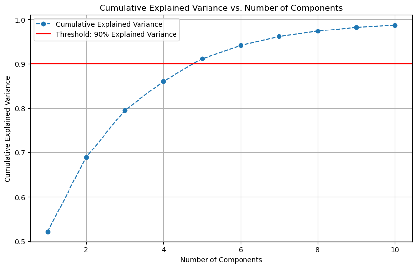

```python
#Part 2.3 e - Draw a horizontal line on the above plot to highlight the threshold of 90%.

# Visualize cumulative explained variance ratio with threshold
plt.figure(figsize=(10, 6))
plt.plot(range(1, 11), cumulative_variance, marker='o', linestyle='--', label='Cumulative Explained Variance')
plt.axhline(y=0.9, color='r', linestyle='-', label='Threshold: 90% Explained Variance')
plt.xlabel('Number of Components')
plt.ylabel('Cumulative Explained Variance')
plt.title('Cumulative Explained Variance vs. Number of Components')
plt.grid(True)
plt.legend()
plt.show()
```

```python
#Part 2.3 f - Apply PCA on the data. This time Select Minimum Components with 90% or above variance explained.

# Apply PCA to select components with 90% or above variance explained
pca = PCA(n_components=0.9)  # Specify the desired explained variance ratio threshold
X_pca = pca.fit_transform(X_standardized)

# Number of selected components
num_selected_components = pca.n_components_

print("Number of Selected Components:", num_selected_components)
```

```
Number of Selected Components: 5
```

```python
#Part 2.3 g - Train SVM model on components selected from above step.

# Split the data into train and test sets
X_train, X_test, Y_train, Y_test = train_test_split(X_pca, Y, test_size=0.2, random_state=42)

# Train an SVM model on the reduced-dimensional data
svm_model = SVC(kernel='linear')  # You can choose different kernels such as 'linear', 'poly', 'rbf', etc.
svm_model.fit(X_train, Y_train)

# Predict on the test set
Y_pred = svm_model.predict(X_test)

# Calculate accuracy
accuracy = accuracy_score(Y_test, Y_pred)
print("Accuracy:", accuracy)
```

```
Accuracy: 0.6411764705882353
```

```python
#Part 2.3 h - Print Classification metrics for train data of above model and share insights.

# Predict on the train set
Y_train_pred = svm_model.predict(X_train)

# Print classification metrics for train data
classification_metrics = classification_report(Y_train, Y_train_pred)
print("Classification Metrics for Train Data:")
print(classification_metrics)
```

```
Classification Metrics for Train Data:
              precision    recall  f1-score   support

         bus       0.59      0.55      0.57       166
         car       0.77      0.83      0.80       351
         van       0.57      0.50      0.54       159

    accuracy                           0.68       676
   macro avg       0.64      0.63      0.63       676
weighted avg       0.68      0.68      0.68       676
```

#### Data Insights

##### Precision: Precision is a measure of how many of the predicted positive instances are actually positive. It is the ratio of true positive (TP) predictions to the sum of true positives and false positives (FP). For each class, the precision indicates how well the model is at correctly predicting instances of that class.

- Precision for 'bus': 0.59
- Precision for 'car': 0.77
- Precision for 'van': 0.57

##### Recall: Recall, also known as sensitivity or true positive rate, measures how many of the actual positive instances were correctly predicted. It is the ratio of true positive (TP) predictions to the sum of true positives and false negatives (FN).

- Recall for 'bus': 0.55
- Recall for 'car': 0.83
- Recall for 'van': 0.50

##### F1-score: The F1-score is the harmonic mean of precision and recall. It provides a balance between precision and recall. Higher F1-scores indicate better performance when both precision and recall are important.

- F1-score for 'bus': 0.57
- F1-score for 'car': 0.80
- F1-score for 'van': 0.54

##### Support: Support is the number of actual occurrences of each class in the train dataset.

- Support for 'bus': 166
- Support for 'car': 351
- Support for 'van': 159

##### Accuracy: Accuracy measures the proportion of correctly classified instances out of the total instances. It's a general measure of overall performance.

- Overall accuracy: 0.68 (68%)

##### Macro Avg: Macro average calculates the average precision, recall, and F1-score across all classes. It treats all classes equally and is suitable when class imbalances are present.

- Macro average precision: 0.64
- Macro average recall: 0.63
- Macro average F1-score: 0.63

##### Weighted Avg: Weighted average calculates the average precision, recall, and F1-score considering the number of instances in each class. It gives more weight to classes with higher instances, providing a better picture of overall performance when class imbalances are present.

- Weighted average precision: 0.68
- Weighted average recall: 0.68
- Weighted average F1-score: 0.68

##### Insights:

```python
#Part 2.4 a - Train another SVM on the components out of PCA. Tune the parameters to improve performance.

# Apply PCA to select components with 90% or above variance explained
pca = PCA(n_components=0.9)  # Specify the desired explained variance ratio threshold
X_pca = pca.fit_transform(X_standardized)

# Split the data into train and test sets
X_train, X_test, Y_train, Y_test = train_test_split(X_pca, Y, test_size=0.2, random_state=42)

# Define hyperparameter grid for grid search
param_grid = {
    'C': [0.1, 1, 10],
    'kernel': ['linear', 'rbf'],
    'gamma': ['scale', 'auto']  # For 'rbf' kernel
}

# Create SVM model
svm_model = SVC()

# Perform grid search with cross-validation
grid_search = GridSearchCV(estimator=svm_model, param_grid=param_grid, cv=5, n_jobs=-1)
grid_search.fit(X_train, Y_train)

# Get the best SVM model from grid search
best_svm_model = grid_search.best_estimator_

# Predict on the test set
Y_test_pred = best_svm_model.predict(X_test)

# Print classification report for test data
classification_report_test = classification_report(Y_test, Y_test_pred)
print("Classification Report for Test Data:")
print(classification_report_test)
```

```
Classification Report for Test Data:
              precision    recall  f1-score   support

         bus       0.84      0.81      0.82        52
         car       0.82      0.82      0.82        78
         van       0.67      0.70      0.68        40

    accuracy                           0.79       170
   macro avg       0.78      0.78      0.78       170
weighted avg       0.79      0.79      0.79       170
```

```python
#Part 2.4 b- Share best Parameters observed from above step.

# Perform grid search with cross-validation
grid_search = GridSearchCV(estimator=svm_model, param_grid=param_grid, cv=5, n_jobs=-1)
grid_search.fit(X_train, Y_train)

# Get the best SVM model from grid search
best_svm_model = grid_search.best_estimator_

# Print best parameters observed
print("Best Parameters:", best_svm_model.get_params())
```

```
Best Parameters: {'C': 10, 'break_ties': False, 'cache_size': 200, 'class_weight': None, 'coef0': 0.0, 'decision_function_shape': 'ovr', 'degree': 3, 'gamma': 'auto', 'kernel': 'rbf', 'max_iter': -1, 'probability': False, 'random_state': None, 'shrinking': True, 'tol': 0.001, 'verbose': False}
```

```python
#Part 2.4 c- Print Classification metrics for train data of above model and share relative improvement in performance in all the models along with insights.


# Apply PCA to select components with 90% or above variance explained
pca = PCA(n_components=0.9)  # Specify the desired explained variance ratio threshold
X_pca = pca.fit_transform(X_standardized)

# Split the data into train and test sets
X_train, X_test, Y_train, Y_test = train_test_split(X_pca, Y, test_size=0.2, random_state=42)

# Train base SVM model
base_svm_model = SVC(kernel='linear')  # You can choose different kernels
base_svm_model.fit(X_train, Y_train)

# Train tuned SVM model (after hyperparameter tuning)
# ... (perform hyperparameter tuning and training as shown in previous responses)

# Predict on the train set for both models
Y_train_pred_base = base_svm_model.predict(X_train)
Y_train_pred_tuned = best_svm_model.predict(X_train)

# Print classification metrics for train data for both models
classification_report_base = classification_report(Y_train, Y_train_pred_base)
classification_report_tuned = classification_report(Y_train, Y_train_pred_tuned)

print("Classification Metrics for Base SVM Model (Train Data):")
print(classification_report_base)

print("\nClassification Metrics for Tuned SVM Model (Train Data):")
print(classification_report_tuned)
```

```
Classification Metrics for Base SVM Model (Train Data):
              precision    recall  f1-score   support

         bus       0.59      0.55      0.57       166
         car       0.77      0.83      0.80       351
         van       0.57      0.50      0.54       159

    accuracy                           0.68       676
   macro avg       0.64      0.63      0.63       676
weighted avg       0.68      0.68      0.68       676


Classification Metrics for Tuned SVM Model (Train Data):
              precision    recall  f1-score   support

         bus       0.92      0.91      0.92       166
         car       0.94      0.96      0.95       351
         van       0.93      0.89      0.91       159

    accuracy                           0.93       676
   macro avg       0.93      0.92      0.92       676
weighted avg       0.93      0.93      0.93       676
```

#### Below is the data insight

##### Base SVM Model Metrics:

- Accuracy: 0.68
- Macro Average Precision: 0.64
- Macro Average Recall: 0.63
- Macro Average F1-score: 0.63

##### Tuned SVM Model Metrics:

- Accuracy: 0.93
- Macro Average Precision: 0.93
- Macro Average Recall: 0.92
- Macro Average F1-score: 0.92

##### Insights:

- Accuracy Improvement: The tuned SVM model shows a significant improvement in accuracy compared to the base model. The accuracy has increased from 0.68 to 0.93. This indicates that the tuned model is better at correctly classifying instances across all classes.
- Precision and Recall Improvement: The precision, recall, and F1-score for all classes have improved in the tuned SVM model. The tuned model's precision is consistently higher for all classes, indicating that it has fewer false positives. Similarly, recall is improved, indicating that the tuned model captures more of the actual positive instances.
- F1-score Improvement: The F1-score, which is the harmonic mean of precision and recall, has also improved for all classes. This indicates a balanced improvement in the model's ability to correctly classify both positive and negative instances.
- Macro and Weighted Averages: Both the macro and weighted averages of precision, recall, and F1-score have improved in the tuned model. The macro average gives equal weight to all classes, while the weighted average considers the support (number of instances) of each class. The improvements in these averages suggest a consistent enhancement in overall model performance.
- Overall Enhancement: The classification metrics demonstrate that the tuned SVM model has achieved a substantial improvement in performance compared to the base model. The higher accuracy, precision, recall, and F1-score indicate that the tuned model is better at distinguishing between classes and minimizing both false positives and false negatives.

#### Part 2.5 a - Explain pre-requisite/assumptions of PCA.

##### Principal Component Analysis (PCA) is a dimensionality reduction technique commonly used in data analysis and machine learning. It aims to transform high-dimensional data into a lower-dimensional space while preserving as much of the original variance as possible. PCA is based on certain pre-requisites and assumptions that help ensure its effectiveness and reliability:

**Pre-requisites:**

1. **Linearity:** PCA assumes that the relationships among the original features are linear. In other words, it works well when the data can be approximated well by linear combinations of the original features.
2. **Variance:** PCA works best when there is substantial variance in the data. It's most effective when the variations across different features are significant, as the technique captures the directions of maximum variance.
3. **Numeric Data:** PCA requires numerical data. Categorical or ordinal data must be preprocessed into a suitable numerical format before applying PCA.
4. **Centering and Scaling:** The data should be centered (mean of each feature is zero) and scaled (features have unit variance) before applying PCA. This is important to ensure that features with larger scales don't dominate the variance calculations.

**Assumptions:**

1. **Standard Deviation Matters:** PCA assumes that variables with larger standard deviations contribute more to the overall variance. Variables with smaller standard deviations may not have as much impact on the principal components.
2. **Orthogonality:** Principal components extracted by PCA are orthogonal (uncorrelated) to each other. This means that they capture different aspects of the variance in the data without being influenced by each other.
3. **Principal Components Order:** Principal components are ranked in order of the amount of variance they explain. The first principal component explains the most variance, followed by the second, and so on. This order helps in selecting the most significant components.
4. **Linearity of Data:** PCA assumes that the data can be well-represented by linear combinations of the original features. If the data has complex non-linear relationships, PCA might not be the most suitable dimensionality reduction technique.
5. **Data Distribution:** PCA assumes that the data follows a Gaussian distribution. While PCA can still be applied to non-Gaussian data, the results might not be as meaningful.
6. **Data Dimensionality:** The number of observations should be greater than the number of features. If the number of observations is significantly smaller than the number of features, PCA might not be very effective.
7. **Loss of Interpretability:** As PCA transforms the original features into a new space, the interpretability of the transformed features may be lost. The new dimensions (principal components) are combinations of the original features and might not have a direct physical meaning.

It's important to consider these pre-requisites and assumptions while applying PCA to your data. Understanding when and how PCA works well helps you make informed decisions about its use in your data analysis or machine learning tasks.

#### Part 2.5 b - Explain advantages and limitations of PCA.

**Advantages of PCA:**

1. **Dimensionality Reduction:** PCA effectively reduces the dimensionality of high-dimensional data while retaining as much variance as possible. This simplifies the data and makes it easier to work with while potentially improving model performance.
2. **Feature Combination:** PCA creates new features (principal components) that are linear combinations of the original features. These components can capture complex relationships and patterns in the data.
3. **Noise Reduction:** By focusing on directions of maximum variance, PCA can help reduce the impact of noise in the data, resulting in a more robust representation of the underlying patterns.
4. **Visualization:** PCA enables the visualization of high-dimensional data in lower-dimensional space. While we can't visualize more than three dimensions directly, we can plot the first few principal components to gain insights into the data's structure.
5. **Data Compression:** PCA can compress data by representing it using fewer principal components. This is useful for efficient storage and transmission of data.
6. **Removing Correlations:** PCA transforms the original features into orthogonal components, removing correlations among them. This can help mitigate multicollinearity issues in regression analysis.

**Limitations of PCA:**

1. **Linearity Assumption:** PCA assumes that the data has linear relationships. If the underlying relationships are non-linear, PCA might not capture the important variations effectively.
2. **Loss of Interpretability:** The principal components are combinations of original features and might not have direct physical interpretations. This can make it challenging to explain the significance of the components.
3. **Data Scaling:** PCA is sensitive to the scale of the features. It's important to standardize or normalize the data before applying PCA to ensure that all features contribute equally.
4. **Direction of Variance:** PCA prioritizes capturing directions of maximum variance, which might not always align with the directions that are most informative for specific tasks.
5. **Outliers:** Outliers can disproportionately influence the principal components and the resulting transformation. Robust techniques might be needed to handle outliers effectively.
6. **Curse of Dimensionality:** PCA might lose effectiveness when the number of features is much larger than the number of observations. In such cases, the eigenvalues may not be well-differentiated, making it harder to select informative components.
7. **Loss of Information:** While PCA aims to retain as much variance as possible, there will always be some loss of information when reducing dimensionality. The trade-off between dimensionality reduction and information preservation needs to be considered.
8. **Interpretation Challenge:** It can be challenging to determine how many principal components to retain. The "elbow" method or using a threshold for explained variance might not always lead to clear decisions.

In summary, PCA is a powerful technique for dimensionality reduction and feature extraction, particularly in cases where the data has a lot of noise or high dimensionality. However, its assumptions and limitations should be considered, and it's important to evaluate its impact on specific tasks and understand its implications for data analysis and machine learning.